# Regulation of opioid receptors and endogenous peptides in the habenula.

Mindy Tran

12/01/2021

Cleaned up version.

# Introduction

Drug overdose represents the leading cause of accidental death in the United States (McLaughlin, Dani, and De Biasi 2017). Specifically, opioids are a highly addictive narcotic that are prescribed for pain management but, when abused, can lead to dependence and overdose(Mistry et al. 2014). There are numerous factors that impact an individual’s risk for dependence, and genetic studies of opioid use suggest that drug use is heritable (Mistry et al. 2014). There is specific interest in the habenula as it has been linked to neuropsychiatric disorders like addiction and depression (Velasquez, Molfese, and Salas 2014), (McLaughlin, Dani, and De Biasi 2017), (Li et al. 2013), (Darcq et al. 2012), (Sivalingam, Ogawa, and Parhar 2020). Drug withdrawal syndromes and aversive states like anxiety and depression share similar physiological manifestations in the habenula. The signaling is linked to reward pathways that include the habenula (McLaughlin, Dani, and De Biasi 2017), thus making the habenula a target to understand the effects of drugs of abuse on the brain (Velasquez, Molfese, and Salas 2014).  
As for opioid binding sites, the opioid receptor gene family includes Oprm1, Oprd1, Oprk1. The endogenous ligands for the opioid receptors form the opioid peptide family and are produced by proteolytic cleavage of three large protein precursors, preproenkephalin (Penk), preprodynorphin (Pdyn), and proopiomelanocortin (Pomc) (Le Merrer et al. 2009). Here, I hope to use data from the Sylwestrak Lab study how chronic morphine use impacts gene expression in the habenula.

In 2015, Mocosko et al. published a paper on a method for Droplet-based single cell sequencing. They created an atlas of gene expression for known and novel candidate mouse retinal subtypes for their dataset (Macosko et al. 2015). This workflow to identify cell populations can be applied to my mice habenula data. A 2018 paper from Pandey et al. also used single single-cell RNA sequencing data to identify dozens of new marker genes that define habenular neuronal types in zebrafish (Pandey 2018). More recently, single-cell RNA sequencing data has been used to determine gene markers for different anatomical regions of the habenula in mice. Specifically, Tac2 and corresponds to the MHb, Gap43 and corresponds to the LHb (Wallace et al. 2020). Recently, a paper from 2020 identified cell-type markers for different brain cell types and habenula cell subtypes (Hashikawa et al. 2020). The markers include:  
- Opalin and Mog marked oligodendrocyte clusters  
- Slc4a4 and Ntsr2 marked astrocyte clusters  
- Pdgfra, Gpr17, or Ccnd1 marked oligodendrocyte precursor cells (OPCs)  
- Tmem119 and C1qc marked microglia  
- Tagln marked the mural cell cluster  
- Cldn5 and Flt1 marked the endothelial cells  
- Fam216b marked ependymal cluster

To address the problem of opioid use and gene expression in the habenula, one study looked at βCaMKII, a kinase that influences the expression and delivery of glutamate receptor GluR1-type AMPAR. The study saw that the kinase may be powerful regulator of LHb neuron function and that βCaMKII is up-regulated in the LHb of animal models of depression (Li et al. 2013). Another study saw that mu opioid receptor-RSK2 signaling in the habenula contributes to morphine analgesia, or the absense of pain, and down-regulation of Ser/Thr kinase RSK2 resulted in reduced analgesia (Darcq et al. 2012).

Overall, past work to study the habenula has offered insight into the mechanisms that drive neuropsychiatric disorders like addiction and depression. I hope to also study the genes related to opioid receptors, endogenous ligands, and their expression in the Sylwestrak Lab’s animal model of addiction. The data I will use is droplet-based single-cell RNA sequencing data. I will compare the gene expression of the control experiment with saline injections, and experiment with morphine injections in mice. Analysis of this data can provide insight into how different neuronal clusters or populations in the habenula drive morphine addiction. I hope to address the affect of chronic morphine use on gene expression in the opioid-related genes. Which cell types show enriched expression of these genes? I predict that the opioid receptor genes (Oprm1, Oprd1, Oprk1) and the endogenous peptides (Penk, Pdyn, POMC) will be up-regulated in our animal model of addiction compared to the control.

# Approach/Methods

The data comes out of the Emily Sylwestrak Lab. Before single-cell RNA sequencing, the mice were perfused before the brain was dissected out. With a vibratome, samples of the habenula were taken in slices and chilled. From the slices, the habenula sections were punched out and enzymatically digested. The habenula sections were dissociated and resuspended, resulting in a concentrated solution of cells. The concentrated cells, were counted with a hemocytometer. Then, 10XGenomics actually does the single-cell mRNA-sequencing (ssRNA seq) library preparation. One of the datasets come from mice that had saline injections and the other will be from mice that had chronic morphine injections.

For the analysis in R, I used tutorials from the Satija lab (Hoffman, Lab, and Collaborators 2019) (Hoffman, Lab, and Collaborators 2021). I will determine which cells and cell populations have high expression of the genes of interest. Also, I will see how the expression differs between the saline and morphine datasets. With violin plots, I will study how chronic morphine use influences the expression of opioid-related genes. With UMAP plots, I hope to visualize and the change in gene expression for individual cell clusters.

**Setup the Seurat objects**  
Here, we set read in the data with the Read10x() function to get a matrix with the amount of each gene for each cell. Then, CreateSeuratObject() is used as a container to hold the data of the saline and morphine data. Afterwards, I subset the data based on total number of molecules detected within a cell (between 600 and 2400) an percentage of mitocondrial (mt) RNA, which I want to be less than 2%. If a cell has a high percentage of mitocondrial RNA, it is likely that that the droplet had the RNA of a lysed cell. So, we want to remove the droplets that do not have a viable cell or that have the RNA of a lysed cell.

Then, I normalize the data and use FindVariableFeatures() to determine a subset of genes have high variation between cells. The genes are highly-expressed in some cells and lowly expressed in others.

**Perform integration and integrated analysis**  
First, FindIntegrationAnchors() and IntegrateData() integrates the control and morphine datasets together. Now we can run a single integrated analysis on all cells. First, I scaled the data before using RunPCA() to perform principal component analysis. With FindNeighbors() and FindClusters(), I place cells with similar gene expression together. RunUMAP() uses this output for the non-linear dimensional reduction.

**Identify conserved cell type markers**  
Now, to identify the clusters, I need to find the marker genes for in each cluster. Here, I displayed the top 5 genes in each cluster.

|  | p_val | avg_log2FC | pct.1 | pct.2 | p_val_adj | cluster | gene |
| --- | --- | --- | --- | --- | --- | --- | --- |
| 1 | 9.08980017251399e-281 | 0.908005431011312 | 0.693 | 0.501 | 1.81705105448555e-276 | 0 | Camk2n1 |
| 2 | 2.60409607403441e-233 | 0.870463104016753 | 0.649 | 0.461 | 5.20558805199478e-229 | 0 | Snap25 |
| 3 | 6.36634537370979e-191 | 0.870270169804645 | 0.576 | 0.408 | 1.27263244020459e-186 | 0 | 2900097C17Rik |
| 4 | 2.30445813212189e-183 | 0.817786988578074 | 0.567 | 0.385 | 4.60661180611165e-179 | 0 | Calb2 |
| 5 | 4.06900594125004e-164 | 0.896645468050602 | 0.437 | 0.254 | 8.13394287655883e-160 | 0 | Bc1 |
| 6 | 0 | 1.4141782674515 | 0.536 | 0.147 | 0 | 1 | Ecrg4 |
| 7 | 0 | 1.26591352671905 | 0.487 | 0.139 | 0 | 1 | Ccdc153 |
| 8 | 0 | 1.2640469638071 | 0.586 | 0.184 | 0 | 1 | Rarres2 |
| 9 | 0 | 1.25844886184683 | 0.476 | 0.131 | 0 | 1 | Tmem212 |
| 10 | 3.48630209904483e-184 | 1.10343354731887 | 0.336 | 0.104 | 6.96911789599061e-180 | 1 | Rsph1 |

[output cut: 65 more lines]

**Assigning cell type identity to clusters**  
Now, I need to find out cluster identities of all the cells in the tissue sample. I will look for gene markers in the different clusters and label those clusters with the appropriate cell-type name.

I use the published gene markers to determine the cluster identity (Hashikawa et al. 2020).

|  | cluster | cell_type |
| --- | --- | --- |
| 1 | 0 | Neuron |
| 2 | 1 | Neuron |
| 3 | 2 | Neuron |
| 4 | 3 | Astrocyte |
| 5 | 4 | Neuron |
| 6 | 5 | Ependymal |
| 7 | 6 | Oligodendrocyte |
| 8 | 7 | Neuron |
| 9 | 8 | Microglia |
| 10 | 8 | Astrocyte |

[output cut: 8 more lines]

Now, based on the gene markers, I determine the cell-type identity of the clusters and visualize the clusters. To save space in my environment, I removed the tables that I do not need anymore.

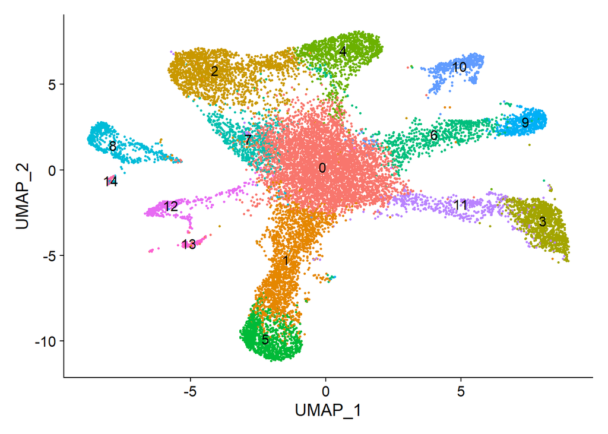

Figure 1: Unnamed cell clusters

```r
### Visualize your named clusters
DimPlot(chronic.combined, reduction = "umap", label = TRUE, pt.size = 0.5) + NoLegend()
```

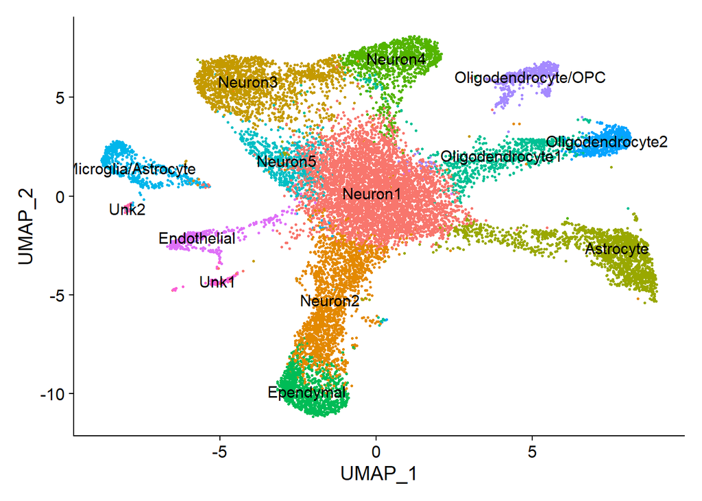

Figure 2: Named cell clusters

```r
### Visualize your named clusters
DimPlot(chronic.combined, reduction = "umap", label = TRUE, pt.size = 0.5) + NoLegend()
```

**Redoing all this with the Neuron clusters only**  
Now, I can subset the neuron clusters and do that whole process again. Here, I visualize our neuronal clusters.

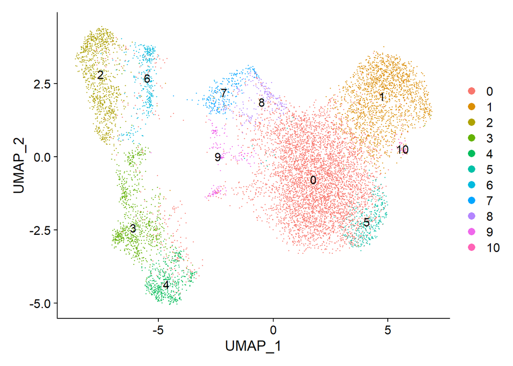

Figure 3: Neuron Clusters

*Find markers for every cluster*  
We can see the top 5 marker genes for the neuron cells. the two right columns show the cluster identity and the gene markers.

|  | p_val | avg_log2FC | pct.1 | pct.2 | p_val_adj | cluster | gene |
| --- | --- | --- | --- | --- | --- | --- | --- |
| 1 | 2.77800661660204e-180 | 0.664135660007996 | 0.803 | 0.634 | 5.55323522658747e-176 | 0 | Plp1 |
| 2 | 3.22936694206439e-164 | 0.777748123788295 | 0.695 | 0.516 | 6.45550451718672e-160 | 0 | Camk2n1 |
| 3 | 1.27942885227268e-138 | 0.814044917757434 | 0.591 | 0.409 | 2.55757827569308e-134 | 0 | 2900097C17Rik |
| 4 | 2.34354933345194e-98 | 0.781168433226997 | 0.457 | 0.289 | 4.68475511757043e-94 | 0 | Bc1 |
| 5 | 7.31808548467302e-87 | 0.723956596003503 | 0.497 | 0.355 | 1.46288528838614e-82 | 0 | Ywhag |
| 6 | 0 | 2.35715307816148 | 0.621 | 0.126 | 0 | 1 | Rarres2 |
| 7 | 0 | 2.14450215381537 | 0.505 | 0.085 | 0 | 1 | Tmem212 |
| 8 | 0 | 2.10829157940878 | 0.554 | 0.098 | 0 | 1 | Ecrg4 |
| 9 | 0 | 2.00581438543229 | 0.508 | 0.1 | 0 | 1 | Ccdc153 |
| 10 | 0 | 1.98823674331548 | 0.426 | 0.072 | 0 | 1 | Pltp |

[output cut: 45 more lines]

# Results

### Identifying the Lateral and Medial Habenula clusters

Using published habenula gene markers (Wallace et al. 2020), I determined which clusters are from the medial and lateral habenula. The medial habenula (MHb) encompass clusters 2, 6, 7, 8 since the gene markers Tac2, Slc17a7, Slc17a6, and Snap25 are highly expressed together in these clusters.

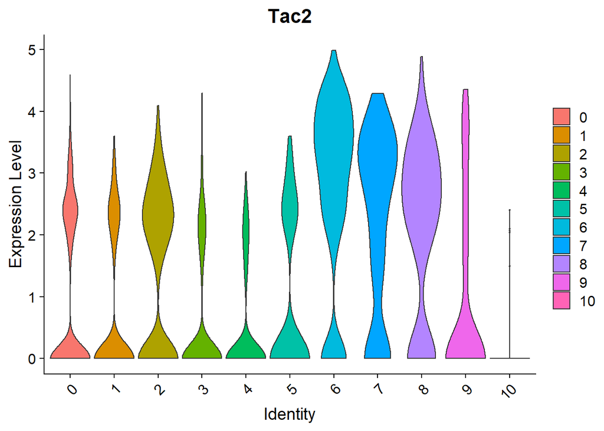

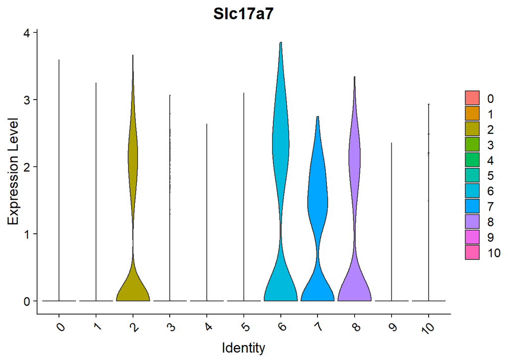

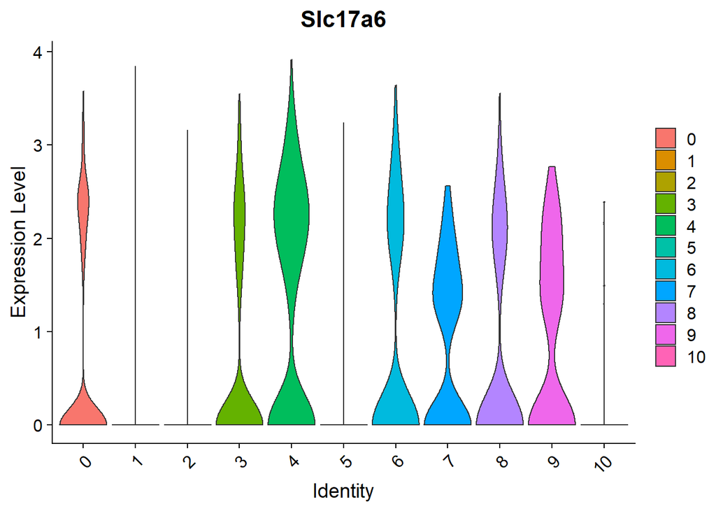

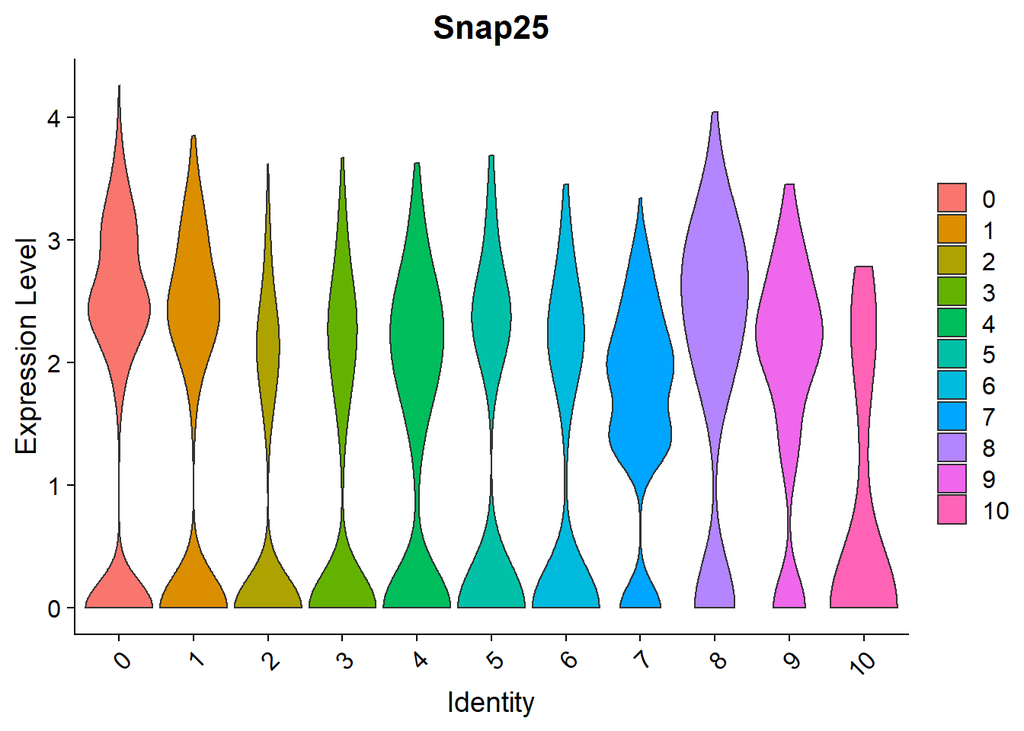

Figure 4: MHb marker genes

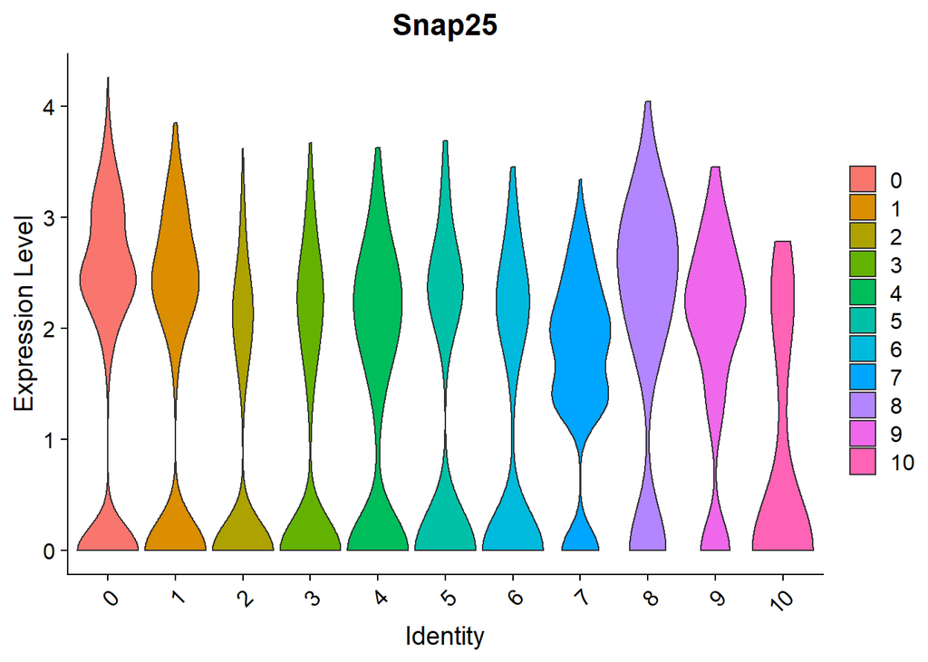

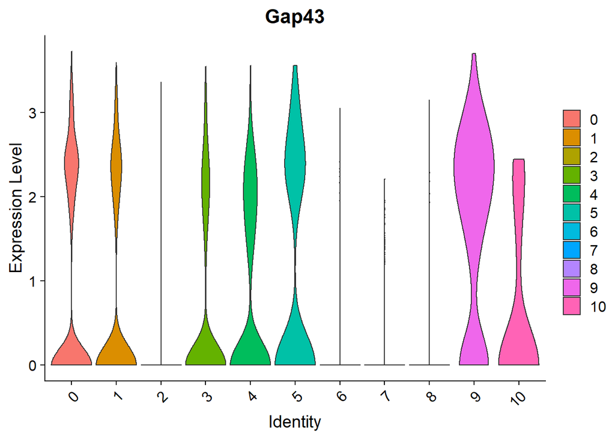

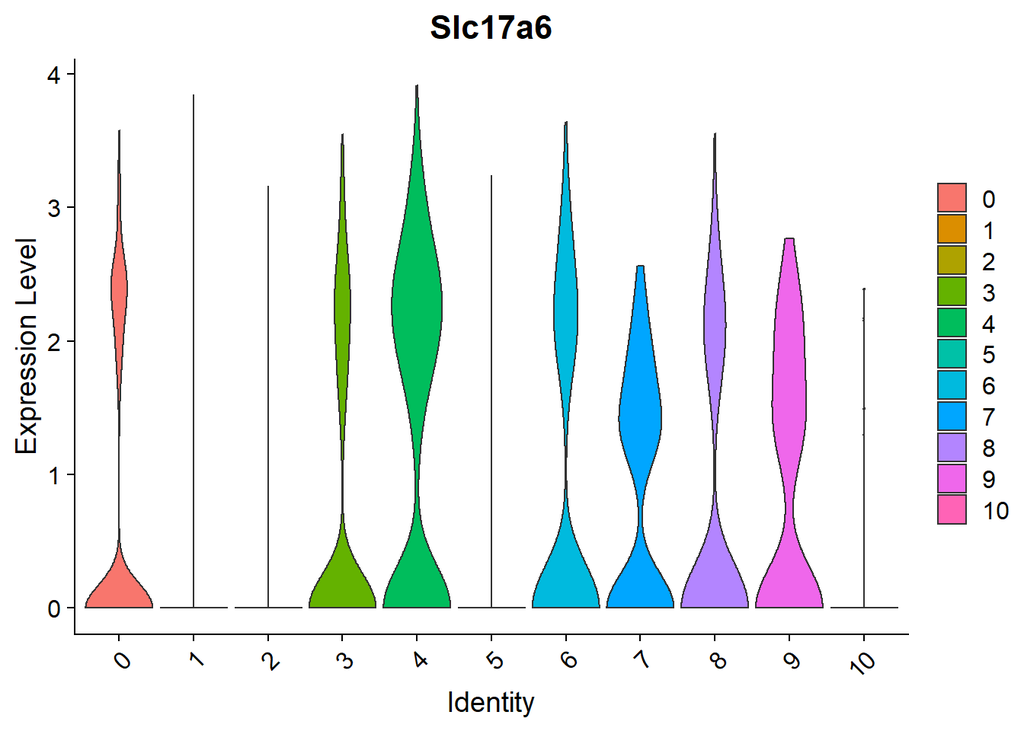

Figure 5: LHb marker genes

We can confirm what we see in the violin plots and see that the genes are localizing in certain clusters. When multiple marker genes are localizing in the same clusters, we can identify the medial habenula (MHb) as clusters 2, 6, 7, 8 and the lateral habenula as clusters 0, 3, 4, 5, 9, 10.

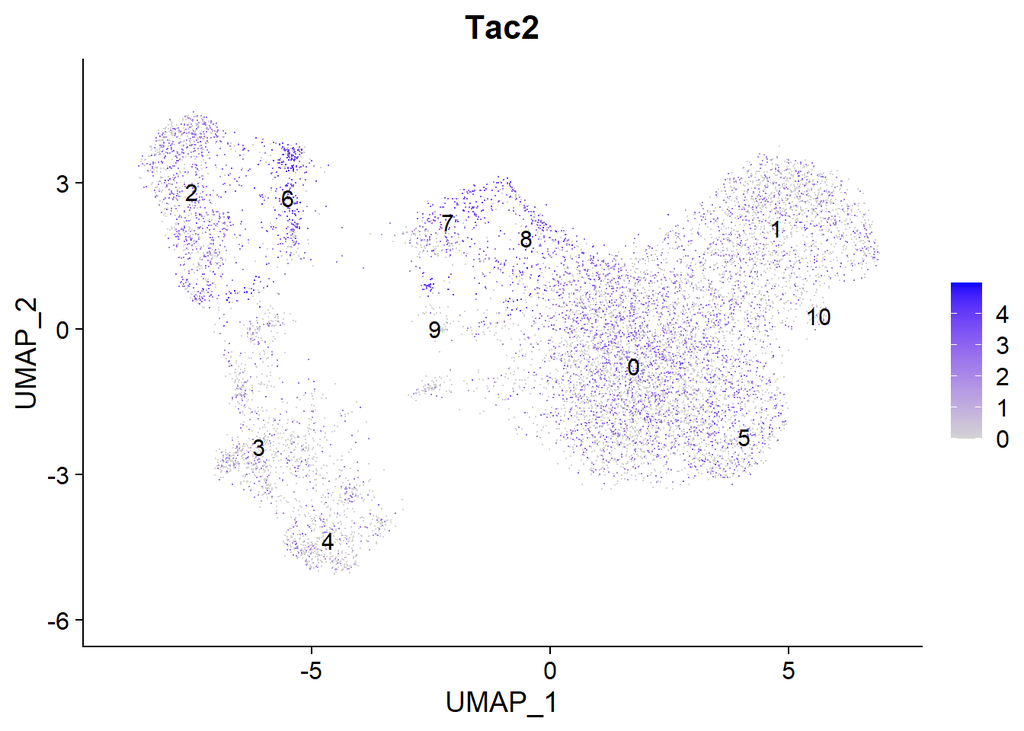

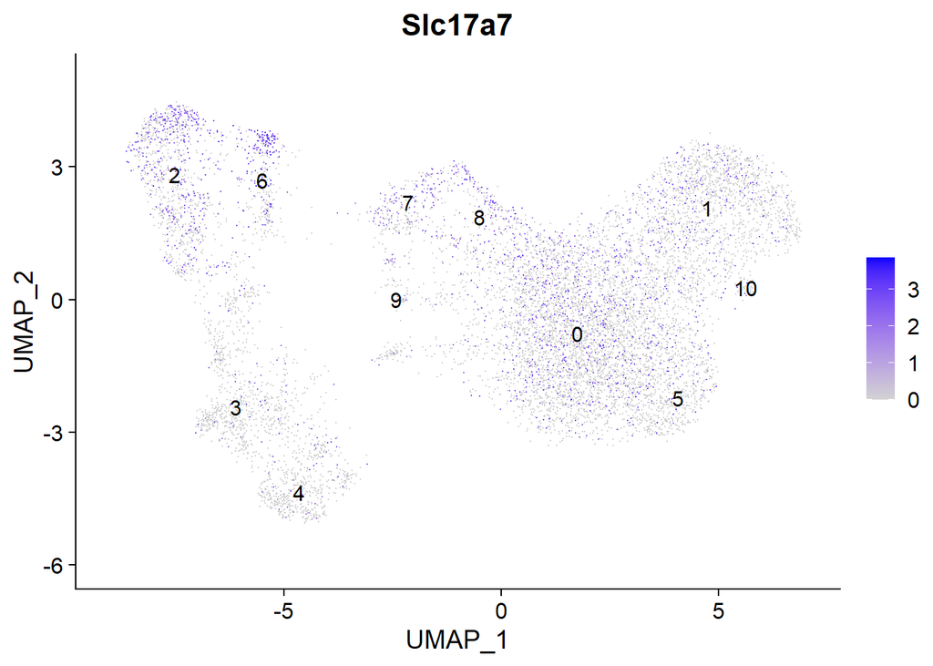

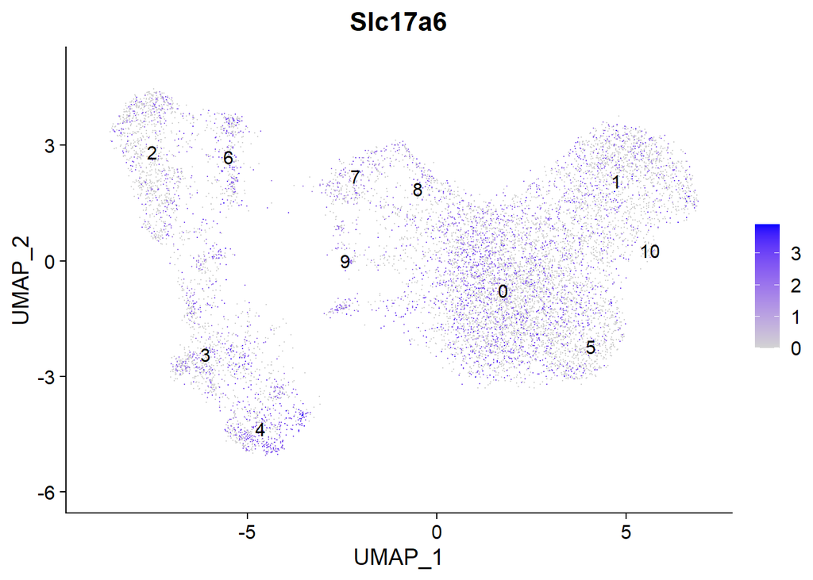

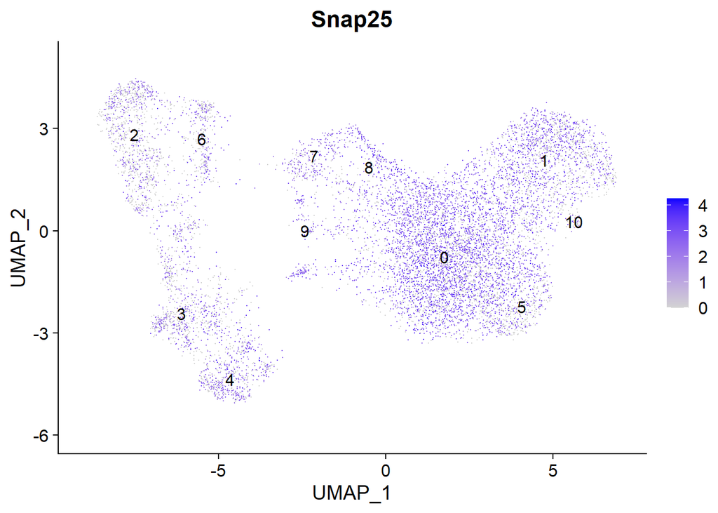

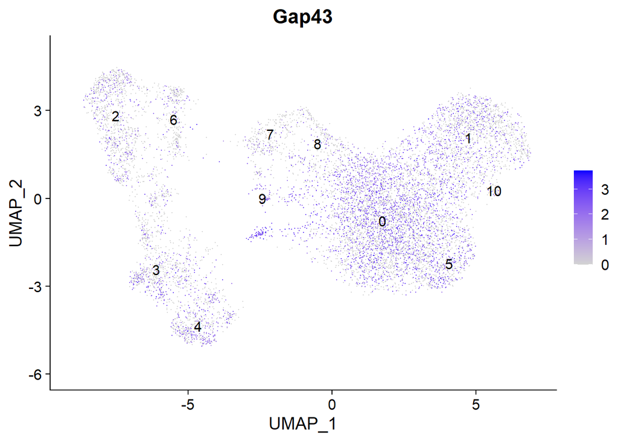

Figure 6: Localization of habenula marker genes

### Oprm1

For the violin plots, for each identity, there is a left and right side. The left side is the control/saline dataset, and the right side is the chronic morphine dataset.

Looking at the opioid receptor genes, Oprm1 is upregulated in cluster 7. Looking at the output of the UMAP dimensional reduction technique, Oprm1 is highly expressed and upregulated in cluster 2 for the saline and morphine injections.

[output not shown]

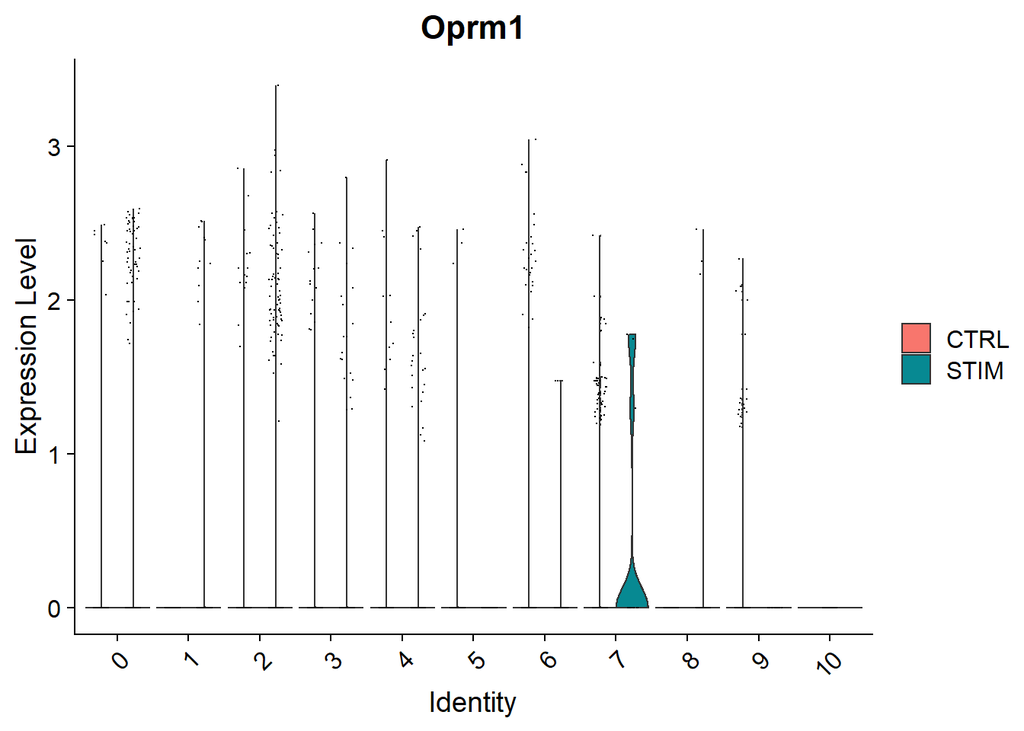

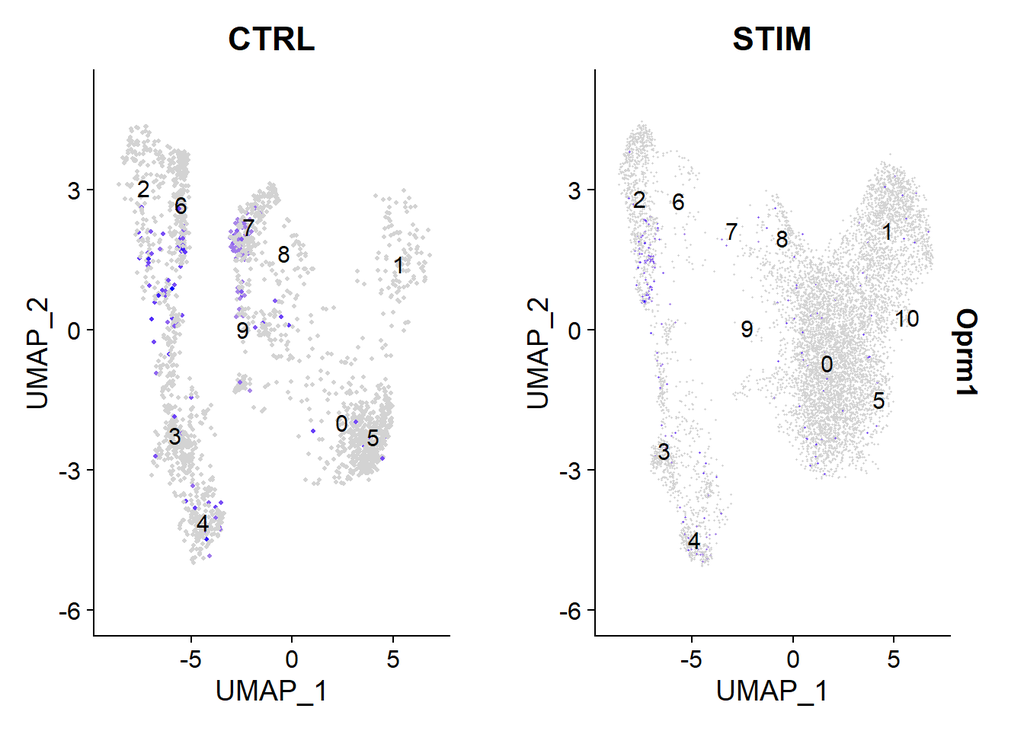

Figure 7: Oprm1 Localization

### Oprk1

From the violin plot, Oprk1 does not seem to have a drastic change in expression like Oprm1. Looking at the output of the UMAP dimensional reduction technique, Oprk1 is highly expressed in cluster 4.

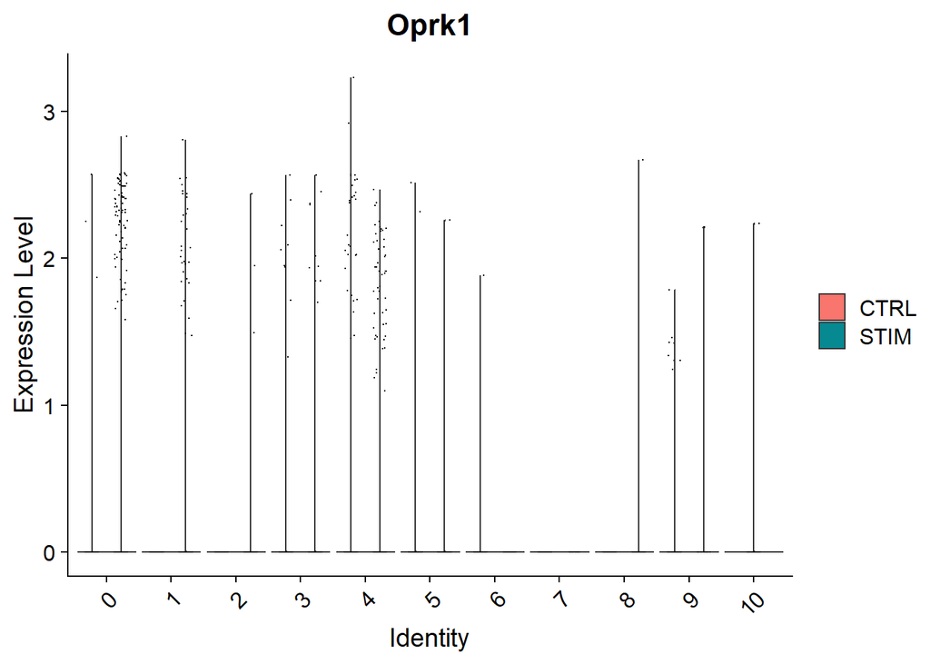

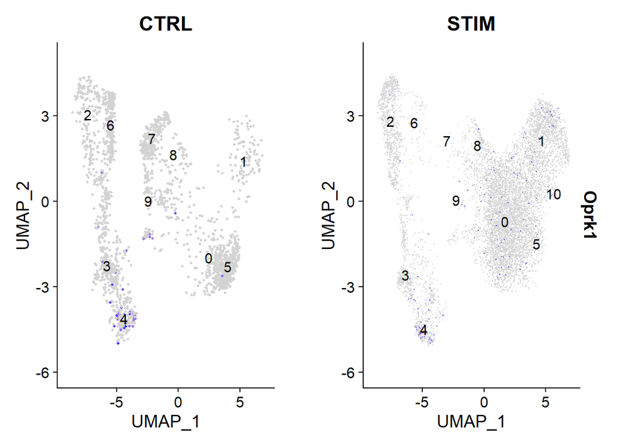

Figure 8: Oprk1 Localization

### Oprd1

For the violin plot of Oprd1, it was not highly expressed in any of the clusters.

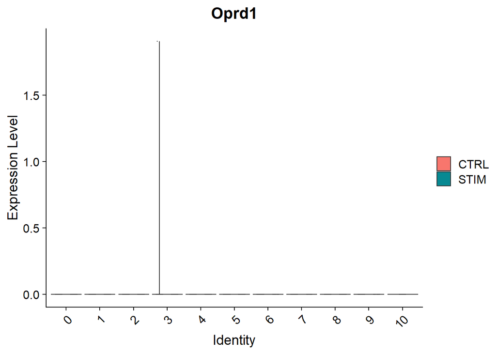

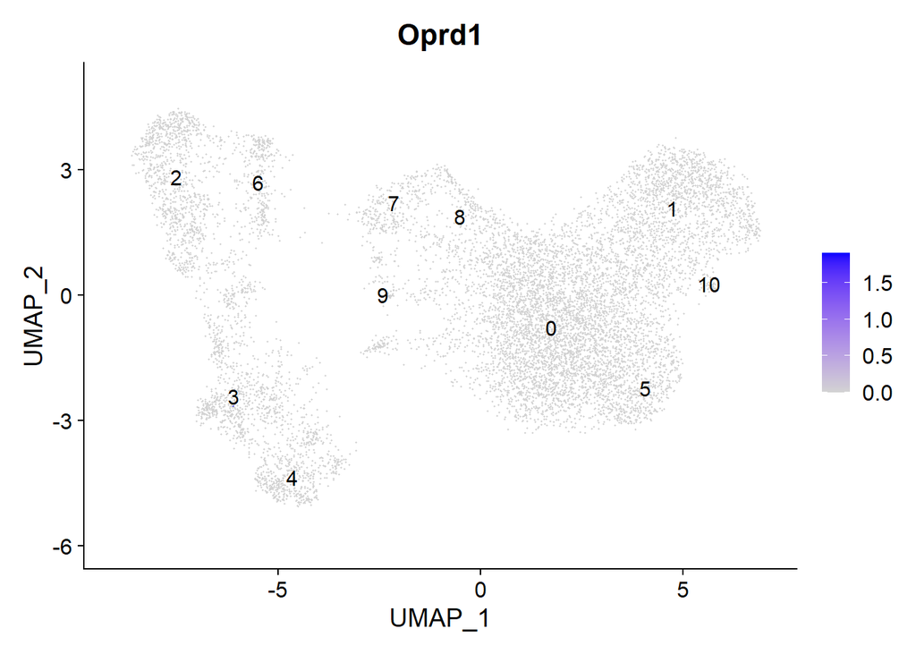

Figure 9: Oprd1 Localization

### Endogenous peptides

From the violin plots, there the clusters have a small number of individual cells that have high expression of the endogenous peptides genes. The overall expression is low in all clusters, which is why the plots are not recognizable as violin plots. Looking at the output of the UMAP dimensional reduction technique:  
- Pomc is highly expressed in cluster 5, seen in the UMAP plot. The violin plot shows more highly-expressing cells in clusters 0, 1, and 2. There are less highly-expressing cells in clusters 5, 6, 7, and 9.  
- Penk has more highly-expressing cells in cluster 0 after chronic morphine use, but the expression level is lower after morphine use. It is upregulated in cluster 1, and down regulated in cluster 3.  
- Pdyn is has more high-expressing cells in cluster 0.  
- The highest expression level in all three is in cluster 3.

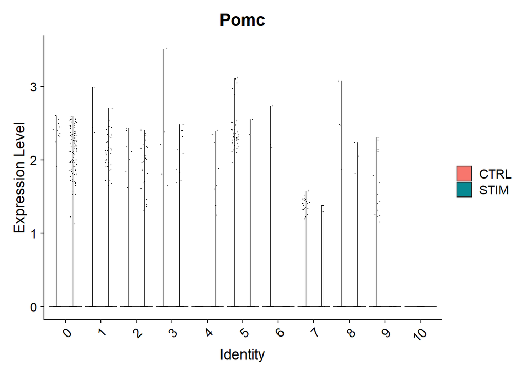

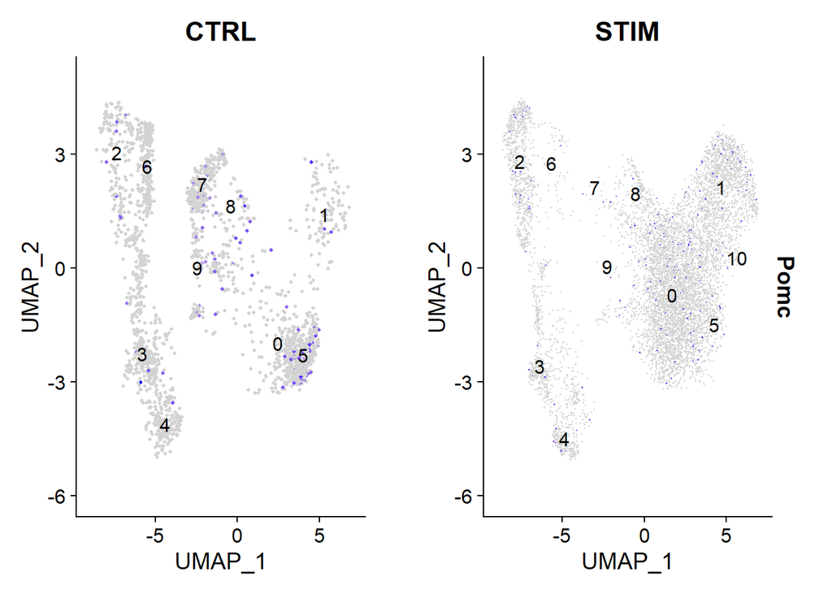

Figure 10: Pomc Localization

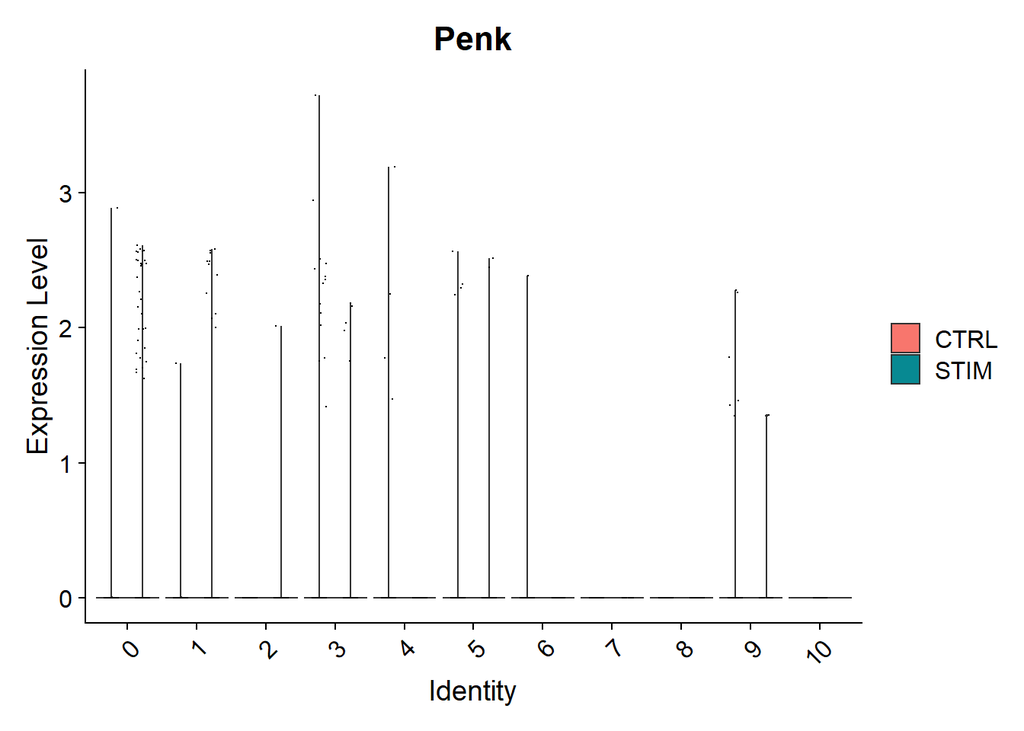

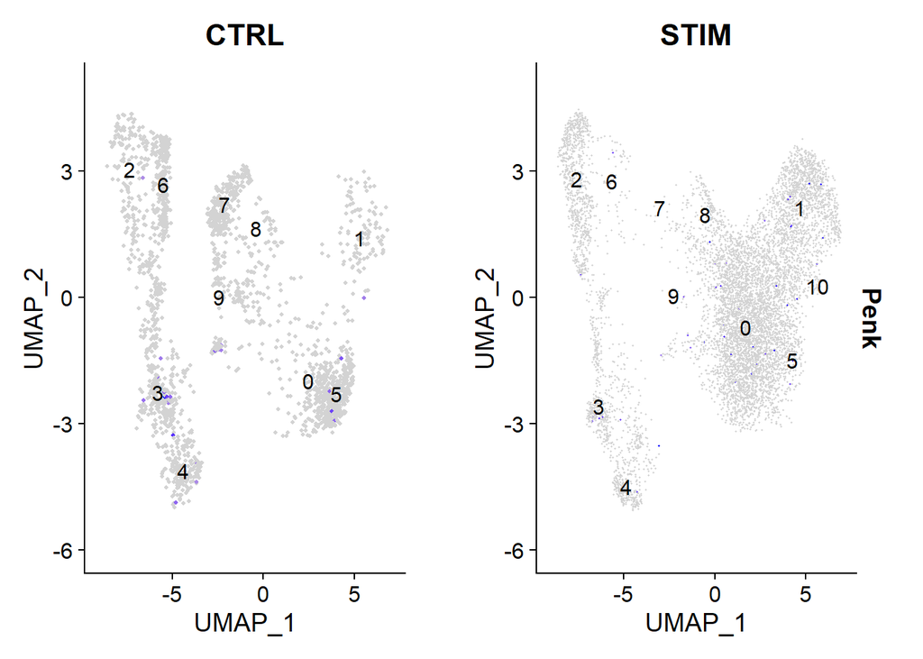

Figure 11: Penk Localization

[figure not shown]

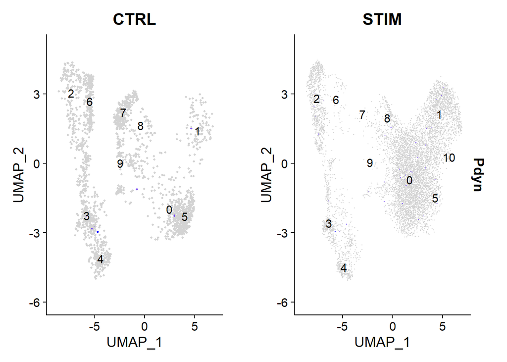

Figure 12: Pdyn Localization

# Discussion

In terms of limitations, the clearest one is the low expression levels. The expression of the opioid receptor and endogenous peptide genes are low across all neuron clusters. While there are individual cells that have high expression levels, the overall gene expression is low in all clusters. The expression was low enough to make the violin plots unrecognizable as violin plots. But the amount of RNA does not confer information about the protein levels in the cell. A cell with a low amount of opioid-related RNA could have high protein levels. That is a limitation to ssRNA sequencing data, it does not convey information about protein expression. With this in mind, I can still provide insight into the change in RNA expression level from chronic morphine use. A future direction could be using in situ hybridization (Wallace et al. 2020) to assess the change in protein expression for these opioid receptor and endogenous peptide genes.

With this study, I hope to address the effect of chronic morphine use on gene expression in the opioid-related genes. I originally sought to see if the lateral and medial habenula as two wholes had a definitive upregulation or down regulation of the opioid-related genes. My original hypothesis was that the opioid receptor and endogenous peptides would be upregulated in the habenula in the model of addiction. But the data suggests that, within both the lateral and medial habenula, there are smaller populations with differing functions in terms of driving addiction. Adding to the current field, this study adds another dataset to further analyze the impact chronic morphine use has on gene expression in the habenula and suggests that there are cell populations within the habenula that impact the mechanisms that drive addiction.

# Bibliographies

Darcq, Emmanuel, Katia Befort, Pascale Koebel, Solange Pannetier, Megan K Mahoney, Claire Gaveriaux-Ruff, André Hanauer, and Brigitte L Kieffer. 2012. “Rsk2 Signaling in Medial Habenula Contributes to Acute Morphine Analgesia.” *Neuropsychopharmacology* 37 (5): 1288–96. https://doi.org/10.1038/npp.2011.316.

Hashikawa, Yoshiko, Koichi Hashikawa, Mark A. Rossi, Marcus L. Basiri, Yuejia Liu, Nathan L. Johnston, Omar R. Ahmad, and Garret D. Stuber. 2020. “Transcriptional and Spatial Resolution of Cell Types in the Mammalian Habenula.” *Neuron* 106 (5): 743–758.e5. https://doi.org/https://doi.org/10.1016/j.neuron.2020.03.011.

Hoffman, Paul, Satija Lab, and Collaborators. 2019. “Tutorial: Integrating Stimulated Vs.&nbsp;control PBMC Datasets to Learn Cell-Type Specific Responses.” *Tutorial: Integrating Stimulated Vs.&nbsp;control PBMC Datasets to Learn Cell-Type Specific Responses*. https://satijalab.org/seurat/archive/v3.0/immune_alignment.html.

———. 2021. “Seurat - Guided Clustering Tutorial.” *Seurat*. https://satijalab.org/seurat/articles/pbmc3k_tutorial.html#identification-of-highly-variable-features-feature-selection-.

Le Merrer, Julie, Jérôme A. J. Becker, Katia Befort, and Brigitte L. Kieffer. 2009. “Reward Processing by the Opioid System in the Brain.” *Physiological Reviews* 89 (4): 1379–1412. https://doi.org/10.1152/physrev.00005.2009.

Li, Kun, Tao Zhou, Lujian Liao, Zhongfei Yang, Catherine Wong, Fritz Henn, Roberto Malinow, John R. Yates, and Hailan Hu. 2013. “;CaMKII in Lateral Habenula Mediates Core Symptoms of Depression.” *Science* 341 (6149): 1016–20. https://doi.org/10.1126/science.1240729.

Macosko, Evan Z., Anindita Basu, Rahul Satija, James Nemesh, Karthik Shekhar, Melissa Goldman, Itay Tirosh, et al. 2015. “Highly Parallel Genome-Wide Expression Profiling of Individual Cells Using Nanoliter Droplets.” *Cell* 161 (5): 1202–14. https://doi.org/https://doi.org/10.1016/j.cell.2015.05.002.

McLaughlin, Ian, John A. Dani, and Mariella De Biasi. 2017. “The Medial Habenula and Interpeduncular Nucleus Circuitry Is Critical in Addiction, Anxiety, and Mood Regulation.” *Journal of Neurochemistry* 142 (S2): 130–43. https://doi.org/https://doi.org/10.1111/jnc.14008.

Mistry, Chetna, Monica Bawor, Dipika Desai, David Marsh, and Zainab Samaan. 2014. *Current Psychiatry Reviews* 10 (2): 156–67. https://doi.org/10.2174/1573400510666140320000928.

Pandey, Karthik Shekhar, Shristi. 2018. “Comprehensive Identification and Spatial Mapping of Habenular Neuronal Types Using Single-Cell RNA-Seq.” *Current Biology* 28: e51271. https://doi.org/https://doi.org/10.1016/j.cub.2018.02.040.

Sivalingam, Mageswary, Satoshi Ogawa, and Ishwar S. Parhar. 2020. “Mapping of Morphine-Induced Oprm1 Gene Expression Pattern in the Adult Zebrafish Brain.” *Frontiers in Neuroanatomy* 14: 5. https://doi.org/10.3389/fnana.2020.00005.

Velasquez, Kenia, David Molfese, and Ramiro Salas. 2014. “The Role of the Habenula in Drug Addiction.” *Frontiers in Human Neuroscience* 8: 174. https://doi.org/10.3389/fnhum.2014.00174.

Wallace, Michael L, Kee Wui Huang, Daniel Hochbaum, Minsuk Hyun, Gianna Radeljic, and Bernardo L Sabatini. 2020. “Anatomical and Single-Cell Transcriptional Profiling of the Murine Habenular Complex.” Edited by Mary Kay Lobo, Kate M Wassum, Mary Kay Lobo, and Manuel Mameli. *eLife* 9 (February): e51271. https://doi.org/10.7554/eLife.51271.